# Beginners Social Networks Course: Session 2

Matthew Silk

2025-10-20

In this session we are going to cover the basics of descriptive measures of social networks, paying attention to their biological meaning in different contexts.

First we need to load the R packages we will use. You may need to install these if you haven’t used them before using the `install.packages()` command in R

```r
set.seed(1)

library(igraph)
library(asnipe)
library(viridis)
library(sna)
library(tnet)
library(boot)
library(corrplot)
library(ggplot2)
```

First of al we are going to read in the `full_adj` adjacency matrix which we will use for a lot of today’s analyses. We will make a weighted version of the network and then create an igraph object.

We then adapt code from the last session to add attributes to the network object and plot the network. You can try changing aspects of this if you want.

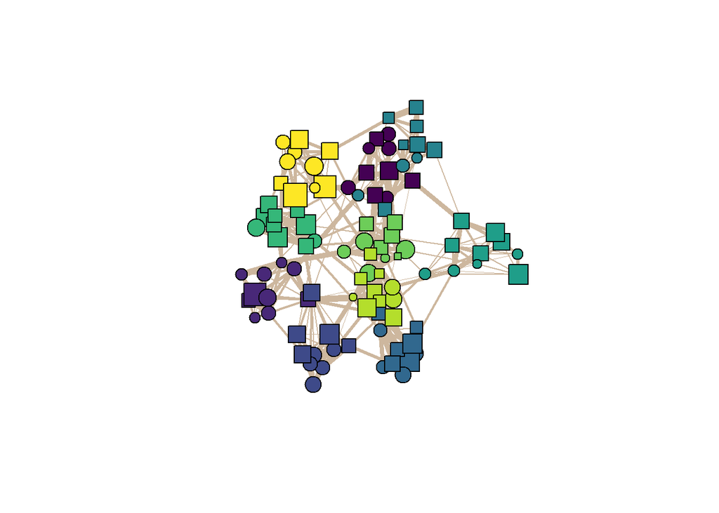

```r
#Read in the network object
full_adj<-readRDS("full_adj.RDS")
#Read in associated trait data
ind_data<-readRDS("ind_data.RDS")
names(ind_data)[1]<-"id"

#Create a weighted version - we are adding edge weights from a beta distribution
full_adj_weight<-full_adj
full_adj_weights<-rbeta(sum(upper.tri(full_adj)),2,7)
full_adj_weight[upper.tri(full_adj_weight)]<-full_adj_weights*full_adj_weight[upper.tri(full_adj_weight)]
full_adj_weight[lower.tri(full_adj_weight)]<-t(full_adj_weight)[lower.tri(full_adj_weight)]

#Create the network object
network<-igraph::graph_from_adjacency_matrix(full_adj_weight,mode="undirected",weighted=TRUE)
igraph::V(network)$size<-5+ind_data$offspring
igraph::V(network)$sex<-ind_data$sex
igraph::V(network)$group<-ind_data$group

#Plot the network object
cols<-viridis(10)
plot(network,vertex.label=NA,vertex.shape=ifelse(V(network)$sex=="M","square","circle"),vertex.color=cols[V(network)$group],edge.width=round(10*E(network)$weight),edge.color="bisque3")
```

We are also going to create a directed network to use an example in our analyses. It will be the matrix `dir_mat` and the network object `dir_net`.

```r
#Create 40 individuals and give them each a size
inds2<-seq(1,40,1)
size2<-rnorm(40,0,1)

#Create a directed edgelist for their interactions
el_dom<-matrix(NA,nr=2000,nc=2)
for(i in 1:nrow(el_dom)){
  t_i1<-sample(inds2,1,prob=0.1+size2+abs(min(size2)))
  t_i2<-sample(inds2[-t_i1],1)
  size_diff<-size2[t_i1]-size2[t_i2]
  winner<-rbinom(1,1,boot::inv.logit(size_diff))
  if(winner==1){
    el_dom[i,1]<-t_i1
    el_dom[i,2]<-t_i2
  }
  if(winner==0){
    el_dom[i,2]<-t_i1
    el_dom[i,1]<-t_i2
  }
}

dir_net<-graph_from_edgelist(el_dom,directed=TRUE)
E(dir_net)$weight<-1
dir_net<-simplify(dir_net, edge.attr.comb=list(weight="sum"))

dir_mat<-as_adjacency_matrix(dir_net,attr="weight",sparse=FALSE)

ind_data2<-data.frame(inds2,size2)
saveRDS(ind_data2,"ind_data2.RDS")
saveRDS(dir_mat,"dir_mat.RDS")
saveRDS(dir_net,"dir_net.RDS")
```

Note that while we have focused on adjacency matrices and edgelists here, networks can also be saved in a number of other formats, especially in other software. The `read_graph()`function in igraph ([here](https://r.igraph.org/reference/read_graph.html)) is helpful to read these network files into R. A common example is the *.graphml* file type. This can be read into R with code such as: `read_graph(file="<network_name>.graphml",format="graphml")`

We now have some networks we can use in demonstrating many of the descriptive measures used in social network analysis.

## SESSION 2: PART 2

### Calculating centrality measures for networks

We will now work through the centrality measures from the powerpoint slides and demonstrate how to calculate different ones. Calculating degree and strength is straightforward in igraph or directly from the adjacency matrix.

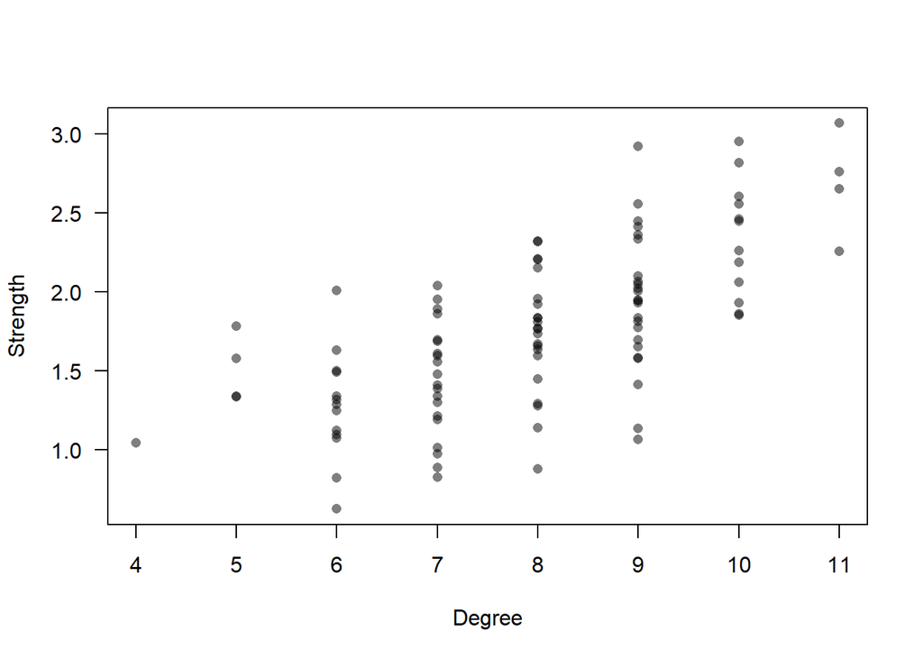

```r
#Calculate degree using igraph
deg<-igraph::degree(network)

#Calculate degree directly from the matrix
deg2<-colSums(sign(full_adj))

#Calculate strength using igraph
stre<-strength(network)

#Calculate strength directly from the matrix
stre2<-colSums(full_adj)

#We could then see, for example, how strength and degree are related to each other in our network
plot(stre~deg,pch=16,col=adjustcolor("black",0.5),las=1,xlab="Degree",ylab="Strength")
```

So in the `full_adj` network there is a strong positive correlation between the number of connections you have and the total weight of those connections, which we might expect in many (but not all) social systems.

igraph also makes it is easy to calculate in-degree and out-degree in directed networks.

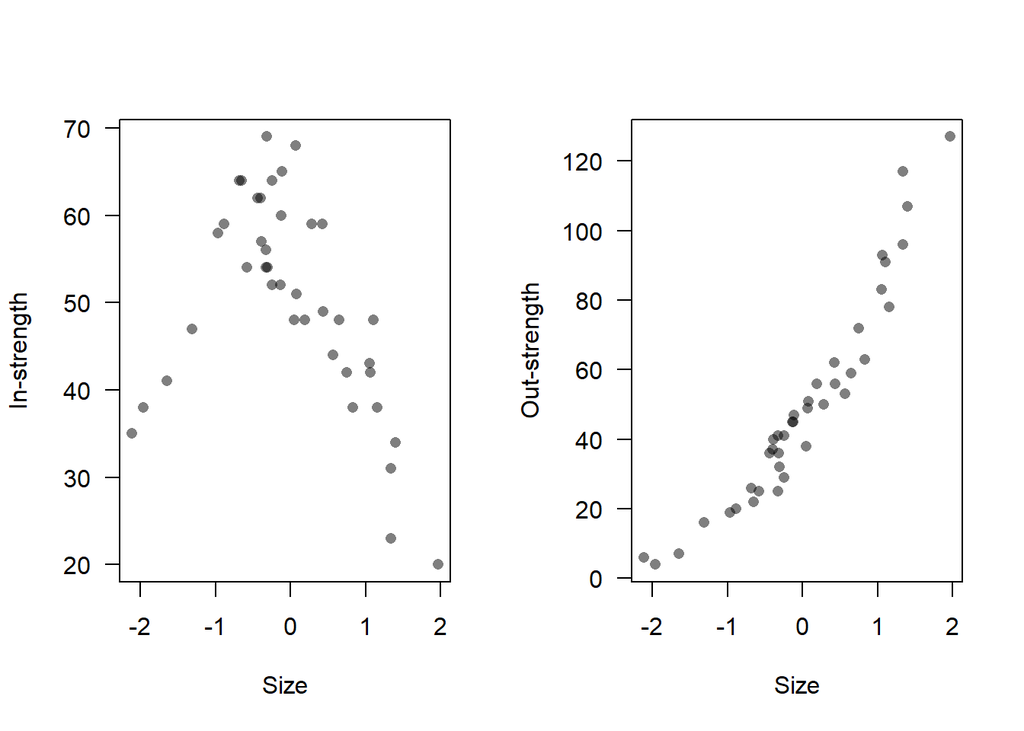

```r
#Here we calculate in-strength and out-strength as an example
instre<-strength(dir_net,mode="in")
outstre<-strength(dir_net,mode="out")

#So we could ask if in-strength and out-strength are related to size in this network
par(mfrow=c(1,2))
plot(instre~ind_data2$size2,pch=16,col=adjustcolor("black",0.5),las=1,xlab="Size",ylab="In-strength")
plot(outstre~ind_data2$size2,pch=16,col=adjustcolor("black",0.5),las=1,xlab="Size",ylab="Out-strength")
```

If you are feeling confident then go back to the model where we generated the directed network and see if you can work out why these relationships exist.

The next level of node-level centrality measures are related to eigenvector centrality - measuring the influence of a node in a way that incorporates its second-order connections (or friends of friends).

It is easy to calculate the eigenvector centrality and variants in igraph for undirected and directed networks

```r
#Calculate eigenvector centraliy for an undirected network
evcent1<-igraph::eigen_centrality(network)

#Note that to print the result you need to extract the $vector component of the object generated
evcent1$vector
```

```
##   [1] 0.072554649 0.103515056 0.050077298 0.081054822 0.053828385 0.052592074
##   [7] 0.068731050 0.296878605 0.066861032 0.099138351 0.066223954 0.332232952
##  [13] 0.125192805 0.049520175 0.050883245 0.083248169 0.057458698 0.099224133
##  [19] 0.132322529 0.103291374 0.139285541 0.067734487 0.055480457 0.040795887
##  [25] 0.042104071 0.031622562 0.029440584 0.033208851 0.049564712 0.027265765
##  [31] 0.110644429 0.054218820 0.056838637 0.131408720 0.056933274 0.033844553
##  [37] 0.041357241 0.065345194 0.080730321 0.071250956 0.046459270 0.035642479
##  [43] 0.184137495 0.015581589 0.015269604 0.024036735 0.037039491 0.014040763
##  [49] 0.020420851 0.022064961 0.006853853 0.055198788 0.038796708 0.020098423
##  [55] 0.023322190 0.012708787 0.022204565 0.024878028 0.005730861 0.151818026
##  [61] 0.057876590 0.059734536 0.079188687 0.093221111 0.206322187 0.069030479
##  [67] 0.068541718 0.082562007 0.074844257 0.097176827 0.099685327 0.104380743
##  [73] 0.207354030 0.062375464 0.074458048 0.065793900 0.062592544 0.049381596
##  [79] 0.057595582 0.069482552 0.909210800 0.852129932 0.924855598 0.371738015
##  [85] 0.786546844 0.816978403 1.000000000 0.547981475 0.884926381 0.880456933
##  [91] 0.020085273 0.036221168 0.032060425 0.139682791 0.021219182 0.040110517
##  [97] 0.028426956 0.021093147 0.027150585 0.020863097
```

```r
#Calculate the eigenvector centrality of the directed network
evcent2<-igraph::eigen_centrality(dir_net,directed=TRUE)$vector

#You can calculate variants of eigenvector centrality such as PageRank in much the same way. Note that in ?page_rank there are more options to consider
pr2<-igraph::page_rank(dir_net,directed=TRUE)$vector
```

We can see that in directed networks the eigenvector centrality is related more to in-strength than out-strength, which has important implications for how we interpret it as a measure of social influence in this case.

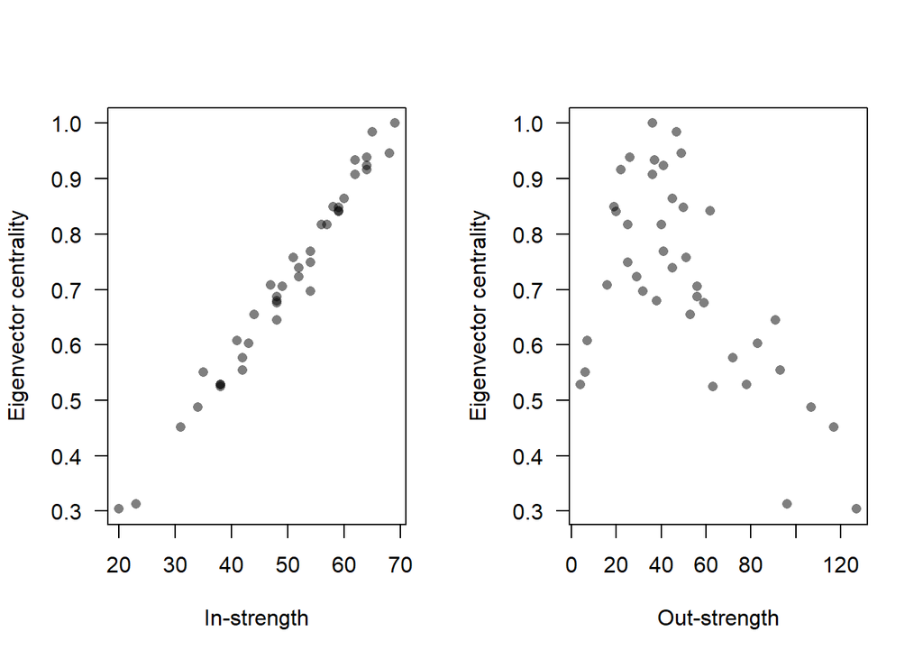

```r
#Plot eigenvector centrality against in-strength and out-strength
par(mfrow=c(1,2))
plot(evcent2~instre,pch=16,col=adjustcolor("black",0.5),las=1,xlab="In-strength",ylab="Eigenvector centrality")
plot(evcent2~outstre,pch=16,col=adjustcolor("black",0.5),las=1,xlab="Out-strength",ylab="Eigenvector centrality")
```

If we want different interpretations of eigenvector centrality then it is possible to use extra arguments in the function to calculate undirected or unweighted versions.

```r
#Calculate the eigenvector centrality of the undirected representation of the network
evcent2a<-igraph::eigen_centrality(dir_net,directed=FALSE)$vector

#Compare the directed and undirected eigenvector centralities
cor.test(evcent2,evcent2a,method="spearman")
```

```
##
##  Spearman's rank correlation rho
##
## data:  evcent2 and evcent2a
## S = 13016, p-value = 0.17
## alternative hypothesis: true rho is not equal to 0
## sample estimates:
##        rho
## -0.2210131
```

```r
#Calculate the eigenvector centrality of the unweighted version
evcent2b<-igraph::eigen_centrality(dir_net,directed=TRUE,weights=NA)$vector

#Compare the weighted and unweighted eigenvector centralities
cor.test(evcent2,evcent2b,method="spearman")
```

```
##
##  Spearman's rank correlation rho
##
## data:  evcent2 and evcent2b
## S = 1582, p-value < 2.2e-16
## alternative hypothesis: true rho is not equal to 0
## sample estimates:
##       rho
## 0.8515947
```

When we look at the correlation between the directed and undirected versions of the eigenvector centrality we can see they represent very different aspects of an individual’s social network position in this network. Therefore, both could help us understand variation in social behaviour.

The unweighted eigenvector centrality is similar to the weighted version in this case, but not the same. In general, you should avoid using unweighted versions of measures when information on edge weights is available, although there are some circumstances where you may be able to justify it.

The final set of centrality measure are the global measures such as *betweenness* and *closeness*. For us, igraph does a less good job at making these easy to calculate because of how it treats edge weights. Therefore we need to be careful, but we do have various options.

In igraph we need to set the weights manually ourselves. For example, we might use the inverse of the edge weights (this is most common). The choice of correction here is not something that has received much research focus, but there are various plausible options that could be chosen.

```r
bet1<-igraph::betweenness(network,weights=1/E(network)$weights)
close1<-igraph::closeness(network,weights=1/E(network)$weights)
```

But we could also use alternative R packages such as [tnet](https://cran.r-project.org/web/packages/tnet/tnet.pdf) or sna

```r
#Create tnet network object from adjacency matrix
tnet_network<-as.tnet(full_adj)
#Calculate global centrality measures
bet2<-tnet::betweenness_w(tnet_network)
close2<-tnet::closeness_w(tnet_network)
```

Note that once again igraph allows you to calculate these global centrality measures for directed networks too. In the case of directed networks, a shortest path can only be in the direction of the edges involved. This means shortest paths will be longer in directed than the equivalent undirected network.

Note that the way of dealing with directed networks is different for betweenness and closeness calculations

```r
#For betweenness we set directed=TRUE
bet2<-igraph::betweenness(dir_net,directed=TRUE,weights=1/E(dir_net)$weights)
#For closeness we can choose mode="in" or mode="out" for directed versions, and mode="all" for an undirected version
close2<-igraph::closeness(dir_net,mode="in",weights=1/E(dir_net)$weights)
```

The final measure mentioned in the powerpoint that we haven’t shown how to calculate is flow betweenness. This is calculated directly from the adjacency matrix in the package [sna](https://cran.r-project.org/web/packages/sna/sna.pdf).

```r
fb1<-sna::flowbet(full_adj_weight)
```

This measure takes much longer to calculate, especially in big networks. It may need a few minutes here.

### Calculating other node-level measures

We also introduced a few additional measures, that aren’t measures of centrality in the same way as the previous measures are. You can see how to calculate these additional measures below.

In igraph we normally would want to choose an option to calculate the weighted clustering coefficient. But look at the options for `type=` to see the other choices you can make.

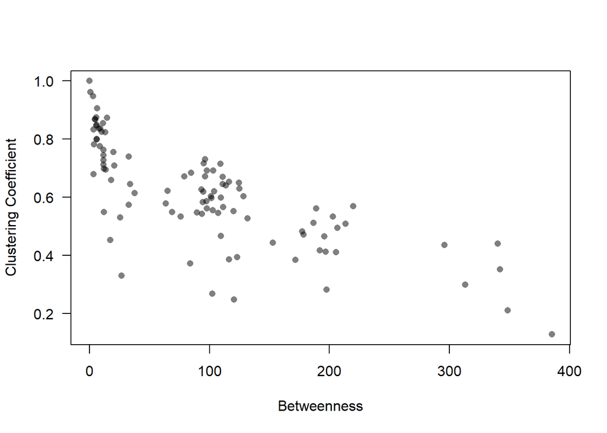

```r
#Clustering coefficient
clust1<-igraph::transitivity(network,type="barrat")

#Plot clustering coefficient against betweenness
plot(clust1~bet1,pch=16,col=adjustcolor("black",0.5),las=1,xlab="Betweenness",ylab="Clustering Coefficient")
```

Not here that in our main network there is a negative relationship between clustering coefficient and betweenness centrality. Perhaps think about why in this sort of network structure this might be the case.

Calculating the coefficient of variation in edge weights is easiest using the adjacency matrix itself. We can calculate two slightly different versions of this measure which can tell us different things about an individual’s social network position: the first includes all possible connections (i.e. including zero edge values), and the second calculates the variation only of completed edges (i.e. ignoring unconnected dyads).

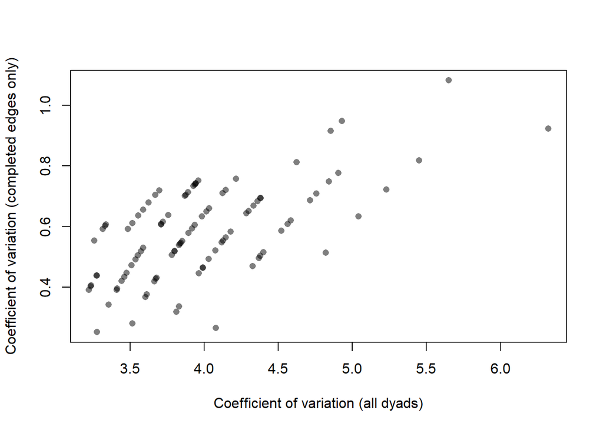

```r
#First we create a new adjacency matrix from full_adj_weight where the diagonal is set to NA
full_adj2<-full_adj_weight
diag(full_adj2)<-NA

#We calculate the coefficient variation for all possible edges
cov_1<-apply(full_adj2,1,sd,na.rm=TRUE)/apply(full_adj2,1,mean,na.rm=TRUE)

#Now we create a third adjacency matrix when all 0 edges are also set to NA
full_adj3<-full_adj2
full_adj3[full_adj3==0]<-NA

#We calculate the coefficient variation only for completed edges
cov_2<-apply(full_adj3,1,sd,na.rm=TRUE)/apply(full_adj3,1,mean,na.rm=TRUE)

#We can see that these two measures aren't necessarily correlated with each other
plot(cov_1,cov_2,pch=16,col=adjustcolor("black",0.5),xlab="Coefficient of variation (all dyads)",ylab="Coefficient of variation (completed edges only)")
```

Collectively these examples provide many of the more common ways to quantify the social network position of an individual, but this list is far from exhaustive and sometimes you may even want to develop your own measures.

The next level of network structure to think about is the neighbourhood of the nodes, or mesoscale structure. Here we will work through community detection as the most important aspect of mescoscale structure.

## SESSION 2: PART 3

### Community detection and modularity

Community detection is a very popular set of tools for researchers working with network analysis. It can provide LOTS of really useful information about a network, but is a tool to use [with caution](https://skewed.de/tiago/blog/descriptive-inferential). Especially in the small and noisy networks we often work with, it can be easy to detect structures when none are there (a problem which can be made worse if you pick the wrong algorithm to find communities).

The different community detection algorithms are:

- cluster_edge_betweenness (nb. edge weights interpreted as distances not connection strengths)
- cluster_fast_greedy (not great to use in small networks)
- cluster_label_prop
- cluster_infomap
- cluster_leading_eigen
- cluster_louvain
- cluster_leiden (updated version of the Louvain algorithm)
- cluster_optimal
- cluster_spinglass
- cluster_walktrap

Information about each method (including some of their strengths and weaknesses) as well as links to the papers where they are first defined are available on the help page for each algorithm.

We can use these algorithms like this:

```r
#You can calculate community membership like this - we use three examples here
comms<-igraph::cluster_infomap(graph=network,e.weights=E(network)$weight)
comms2<-igraph::cluster_louvain(graph=network,weights=E(network)$weight)
#Note that for the cluster_edge_betweenness we get a warning about how it uses edge weights (which is new!)
comms3<-igraph::cluster_edge_betweenness(graph=network,weights=1/E(network)$weight)
```

An important thing to note there is that the object generated by each community detection algorithm is a little different, as each algorithm needs to retain different information or takes a different approach to finding the structure in the network

```r
str(comms)
```

```
## Class 'communities'  hidden list of 5
##  $ membership: num [1:100] 1 1 1 1 1 1 1 1 1 1 ...
##  $ codelength: num 4.95
##  $ vcount    : num 100
##  $ algorithm : chr "infomap"
##  $ modularity: num 0.773
```

```r
str(comms2)
```

```
## Class 'communities'  hidden list of 5
##  $ membership : num [1:100] 1 1 1 1 1 1 1 1 1 1 ...
##  $ memberships: num [1:2, 1:100] 1 1 1 1 2 1 1 1 2 1 ...
##  $ modularity : num [1:2] 0.738 0.773
##  $ vcount     : num 100
##  $ algorithm  : chr "multi level"
```

```r
str(comms3)
```

```
## Class 'communities'  hidden list of 8
##  $ removed.edges   : num [1:399] 56 23 240 54 80 167 77 79 81 62 ...
##  $ edge.betweenness: num [1:399] 367 356 482 344 416 353 351 544 567 862 ...
##  $ merges          : num [1:99, 1:2] 100 98 102 103 101 89 106 90 108 109 ...
##  $ bridges         : num [1:99] 399 398 397 395 392 390 389 387 386 384 ...
##  $ modularity      : num [1:100] -0.01337 -0.01115 -0.00866 -0.00367 0.00421 ...
##  $ membership      : num [1:100] 1 1 1 1 1 1 1 1 1 1 ...
##  $ vcount          : num 100
##  $ algorithm       : chr "edge betweenness"
```

Normally, the thing we are most interested in is `$membership`, which tells us which individuals are in which community

```r
comms$membership
```

```
##   [1]  1  1  1  1  1  1  1  1  1  1  2  2  2  2  2  2  2  2  2  2  3  3  3  3  3
##  [26]  3  3  3  3  3  4  4  4  4  4  4  4  4  4  4  5  5  5  5  5  5  5  5  5  5
##  [51]  6  6  6  6  6  6  6  6  6  6  7  7  7  7  7  7  7  7  7  7  8  8  8  8  8
##  [76]  8  8  8  8  8  9  9  9  9  9  9  9  9  9  9 10 10 10 10 10 10 10 10 10 10
```

```r
comms2$membership
```

```
##   [1]  1  1  1  1  1  1  1  1  1  1  2  2  2  2  2  2  2  2  2  2  3  3  3  3  3
##  [26]  3  3  3  3  3  4  4  4  4  4  4  4  4  4  4  5  5  5  5  5  5  5  5  5  5
##  [51]  6  6  6  6  6  6  6  6  6  6  7  7  7  7  7  7  7  7  7  7  8  8  8  8  8
##  [76]  8  8  8  8  8  9  9  9  9  9  9  9  9  9  9 10 10 10 10 10 10 10 10 10 10
```

```r
comms3$membership
```

```
##   [1]  1  1  1  1  1  1  1  1  1  1  2  2  2  2  2  2  2  2  2  2  3  3  3  3  3
##  [26]  3  3  3  3  3  4  4  4  4  4  4  4  4  4  4  5  5  6  5  5  5  5  5  5  5
##  [51]  7  7  7  7  7  7  7  7  7  7  8  8  8  8  8  8  8  8  8  8  9  9  9  9  9
##  [76]  9  9  9  9  9 10 10 10 10 10 10 10 10 10 10 11 11 11 11 11 11 11 11 11 11
```

We can see that for the main network we are working with the communities are nicely aligned, which we expect as even by eye this network has strong community structure.

As mentioned in the powerpoint a key way to measure the strength of a division into communities is using **modularity** (which is actually used in many of the algorithms to find the optimal community structure). Modularity is a number between (approximately) 0 and 1. Networks with a modularity around 0.3-0.6 could typically be considered to have intermediate levels of community structure, while levels of modularity of 0.7 or above indicate very strong community structure.

We can calculate modularity like this:

```r
modularity(network,comms$membership)
```

[output not shown]

So we can see that our “empirical” network has a strongly modular structure - not surprising given how we created it.

We can calculate a few other things easily from the `communities` (see [here](https://igraph.org/r/doc/communities.html)) object which might be useful, such as:

The size of the social communities:

```r
sizes(comms)
```

```
## Community sizes
##  1  2  3  4  5  6  7  8  9 10
## 10 10 10 10 10 10 10 10 10 10
```

Whether edges connect within or between communities:

```r
crossing(comms,network)
```

```
##   [1] FALSE FALSE FALSE FALSE FALSE FALSE  TRUE FALSE FALSE FALSE FALSE  TRUE
##  [13]  TRUE  TRUE  TRUE FALSE FALSE FALSE FALSE FALSE FALSE FALSE  TRUE FALSE
##  [25] FALSE FALSE FALSE FALSE FALSE FALSE FALSE FALSE  TRUE FALSE FALSE  TRUE
##  [37] FALSE  TRUE FALSE FALSE FALSE FALSE FALSE FALSE FALSE FALSE FALSE FALSE
##  [49] FALSE FALSE FALSE FALSE FALSE  TRUE  TRUE  TRUE FALSE FALSE FALSE FALSE
##  [61] FALSE  TRUE FALSE FALSE FALSE FALSE FALSE FALSE FALSE FALSE FALSE FALSE
##  [73] FALSE FALSE FALSE FALSE  TRUE FALSE  TRUE  TRUE  TRUE FALSE FALSE FALSE
##  [85] FALSE FALSE FALSE FALSE  TRUE  TRUE FALSE FALSE FALSE FALSE FALSE FALSE
##  [97]  TRUE  TRUE FALSE FALSE FALSE FALSE FALSE FALSE FALSE  TRUE FALSE FALSE
## [109] FALSE FALSE FALSE FALSE FALSE FALSE FALSE FALSE FALSE FALSE FALSE  TRUE
## [121] FALSE  TRUE FALSE FALSE FALSE FALSE FALSE FALSE FALSE FALSE  TRUE FALSE
## [133] FALSE FALSE FALSE FALSE FALSE FALSE FALSE FALSE FALSE FALSE FALSE  TRUE
## [145]  TRUE FALSE FALSE FALSE FALSE FALSE  TRUE FALSE FALSE FALSE FALSE FALSE
## [157] FALSE FALSE  TRUE FALSE FALSE FALSE FALSE FALSE  TRUE FALSE FALSE FALSE
## [169] FALSE FALSE FALSE FALSE FALSE FALSE FALSE FALSE FALSE FALSE FALSE FALSE
```

[output cut: 19 more lines]

We can of course, also use our community membership to help us plot the network. There are a couple of potential options here.

The first is to use node colour to represent community membership.

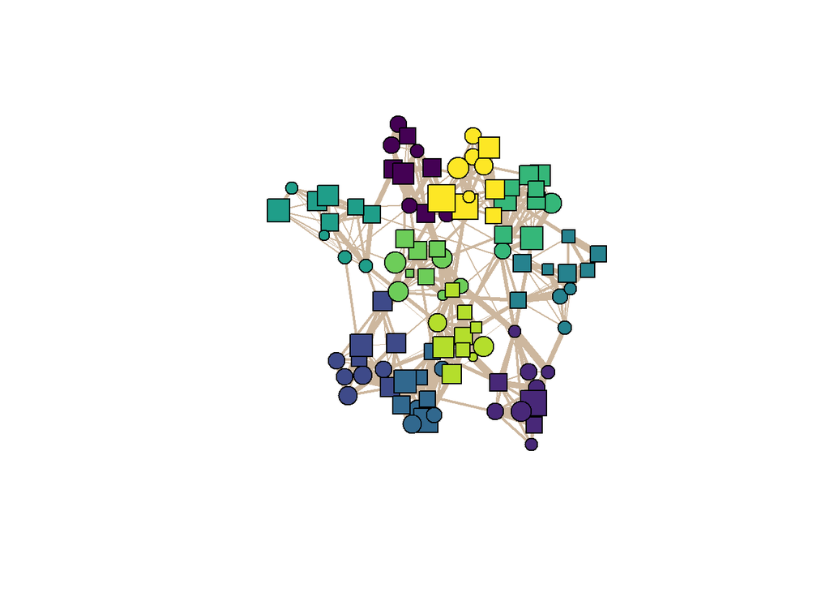

```r
cols<-viridis(10)
plot(network,vertex.label=NA,vertex.shape=ifelse(V(network)$sex=="M","square","circle"),vertex.color=cols[comms$membership],edge.width=round(10*E(network)$weight),edge.color="bisque3")
```

And the second is to mark the communities with polygons in the background of the network. In this plot the node colour is the groups we initially assigned individuals too with the generative model and the background shading is the communities found by the community detection algorithm.

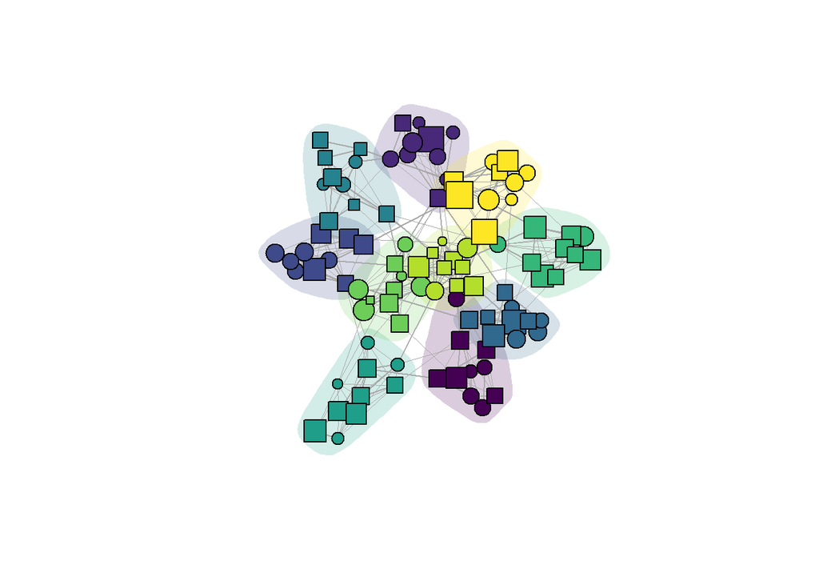

```r
cols<-viridis(10)
plot(comms, network,vertex.label=NA,vertex.shape=ifelse(V(network)$sex=="M","square","circle"),col=cols[V(network)$group],mark.col=adjustcolor(cols,0.2),mark.border=NA,edge.width=round(2*E(network)$weight),edge.color="dark grey")
```

We can see that with this strong community structure, the match is perfect

## SESSION 2: PART 4

In the final part of this session we are going to go through how to calculate a selection of basic network-level or macroscale description of social network structure. I will give examples of how to calculate them using the `network` object to start with, but it would be good to calculate them for some of the other networks in this tutorial and compare the values. You could also generate your own networks to measure!

### Network-level measures

A key thing to note when calculating basic network-level metrics is that some measures require adjustments for edge weights (which otherwise will be treated as costs rather than strengths).

```r
#Calculate DENSITY
igraph::edge_density(network)
```

```
## [1] 0.08060606
```

```r
#Calculate AVERAGE PATH LENGTH
igraph::mean_distance(network,weights=1/E(network)$weight)
```

```
## [1] 13.1154
```

```r
#Calculate (unweighted) TRANSITIVITY
igraph::transitivity(network,type="global")
```

```
## [1] 0.6008273
```

```r
#Calculate EFFICIENCY
igraph::global_efficiency(network,weights=1/E(network)$weight)
```

```
## [1] 0.09313167
```

### Degree distributions

igraph has a specific function for calculating degree distributions, but it is also possible to calculate degree and then using the vector produced as well.

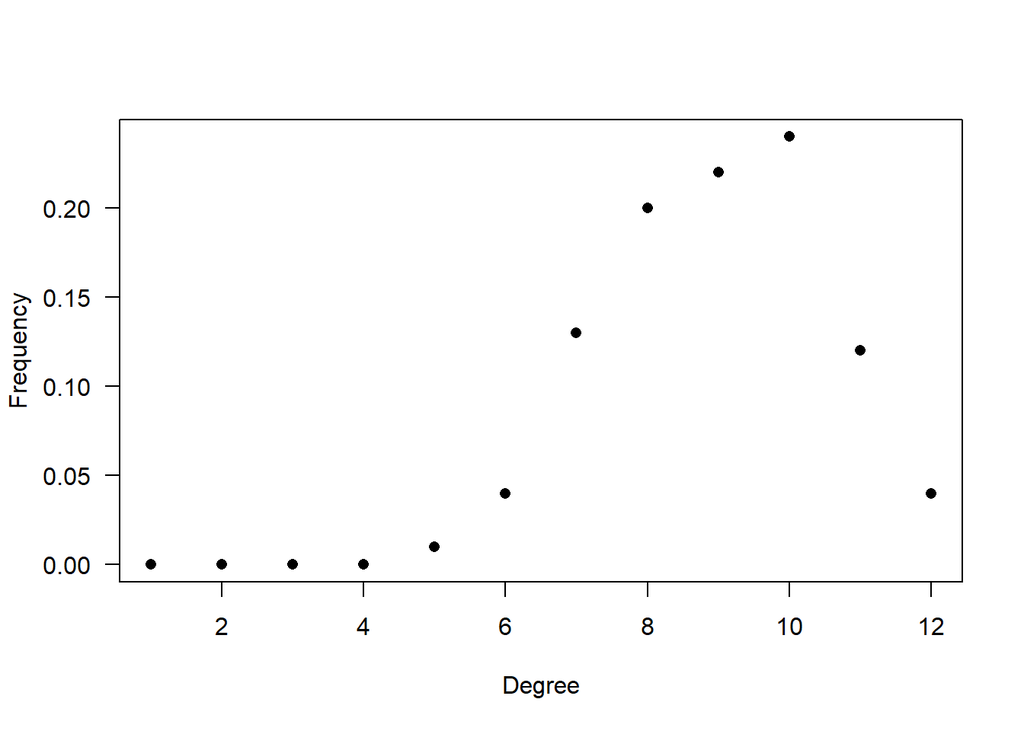

```r
#Conventional degree distribution
deg_dist<-igraph::degree_distribution(network)
plot(deg_dist,las=1,pch=16,xlab="Degree",ylab="Frequency")
```

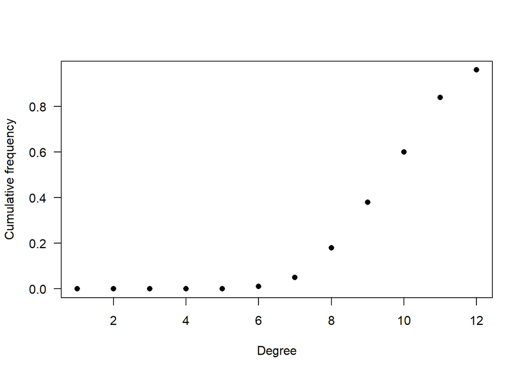

```r
#Cumulative degree distribution (proportion of individuals with a degree of that value or less)
deg_dist<-igraph::degree_distribution(network,cumulative=TRUE)
plot(1-deg_dist,las=1,pch=16,xlab="Degree",ylab="Cumulative frequency")
```

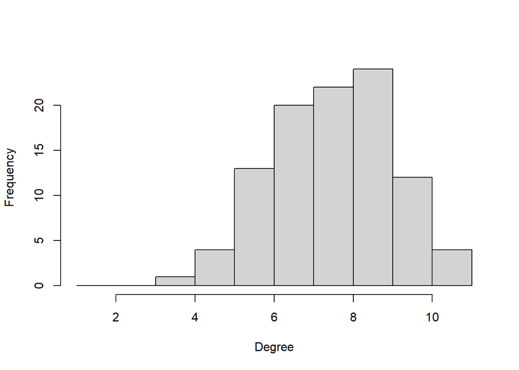

```r
#A histogram version from calculating degree
deg<-igraph::degree(network)
hist(deg,breaks=seq(1,max(deg),1),main="",xlab="Degree")
```

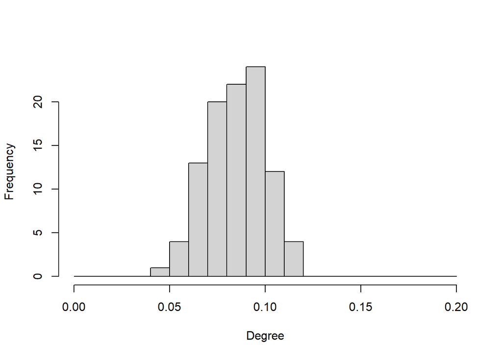

```r
#You may want correct the degree for network size to help with comparisons between networks
deg2<-deg/(gorder(network)-1)
hist(deg2,breaks=seq(0,0.2,0.01),main="",xlab="Degree")
```

### Other metric distributions

We can work in the same with other individual-level measures - the mean, variance of full distribution can capture different aspects of network structure.

```r
#For measures like betweenness we may want to use a correction again (but remember that this correction is different than for degree)
bet<-igraph::betweenness(network,weights=1/E(network)$weight)
bet2<-bet/(gorder(network)^2-gorder(network))

#Mean betweenness
mean(bet2)
```

```
## [1] 0.01399495
```

```r
#Coefficient of variation in betweenness
sd(bet2)/mean(bet2)
```

```
## [1] 0.9893659
```

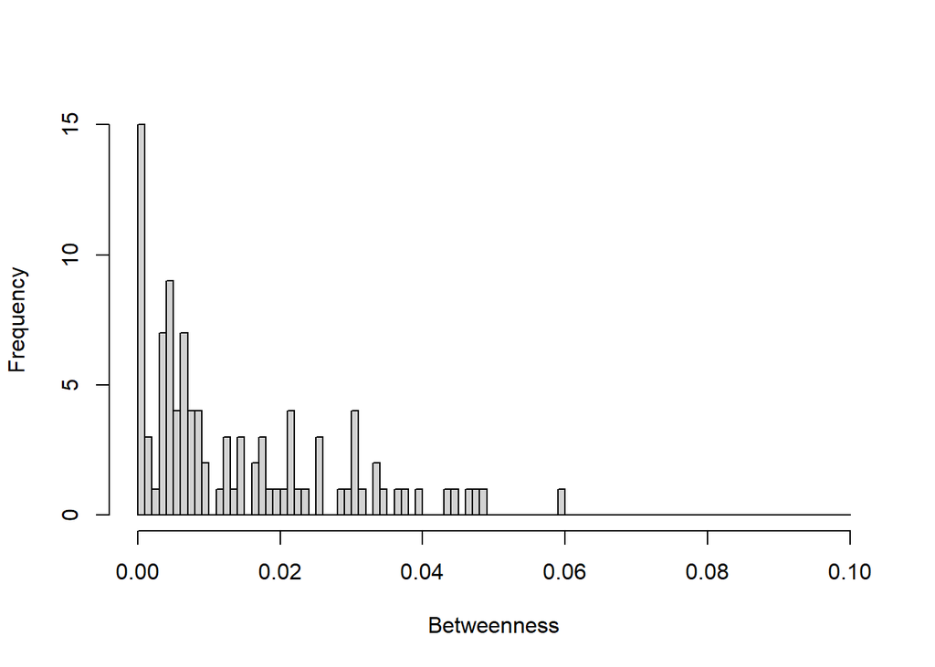

```r
#Full betweenness distribution
hist(bet2,breaks=seq(0,0.1,0.001),main="",xlab="Betweenness")
```

```r
#For other measures like clustering coefficient we don't need to worry so much about corrections
clu<-igraph::transitivity(network,type="barrat")

#Mean clustering coefficient
mean(clu)
```

```
## [1] 0.6126158
```

```r
#Coefficient of variation in clustering coefficient
sd(clu)/mean(clu)
```

```
## [1] 0.2890738
```

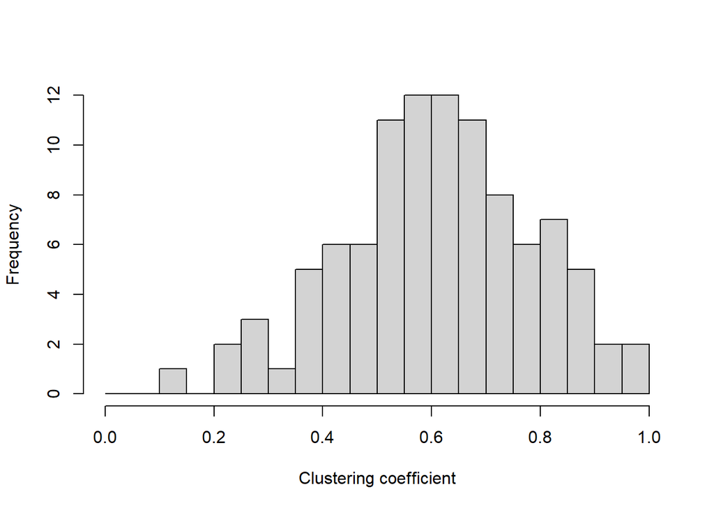

```r
#Full clustering coefficient distribution
hist(clu,breaks=seq(0,1,0.05),main="",xlab="Clustering coefficient")
```

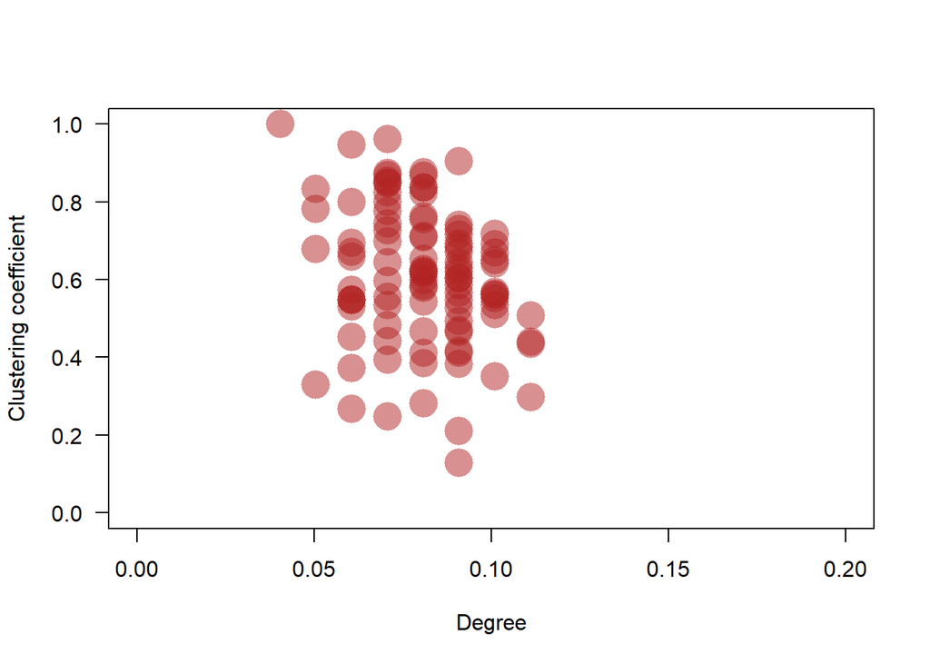

```r
#Finally we may want consider multivariate metric distributions, for example the joint distribution of degree and clustering coefficient
plot(clu~deg2,pch=16,cex=3,col=adjustcolor("firebrick",0.5),xlim=c(0,0.2),ylim=c(0,1),las=1,xlab="Degree",ylab="Clustering coefficient")
```

That covers almost all of the basics of descriptive social network analysis, which leaves us well placed to explore how to conduct statistical inference in networks with the next session.